# Access SA EC2

2015-05-01

## General Information

- EC2 IP Address: http://10.105.18.28/
- EC2 Jump Server IP: http://10.105.0.101/
- SSH Port: 22
- OS: Ubuntu 14.04.1 LTS
- Admin: Greg Allen, Nick Malizia, Kirk Zmijewski

## Services on EC2

[figure not shown]

## Access Info (high-level in English)

In order to access,

1. `ssh` to jump server through **PuTTY**.
2. `ssh` to the EC2 instance from the jump server.

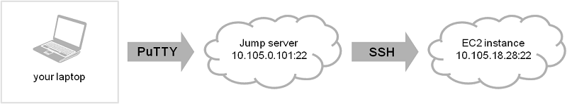

## Access Info (step-by-step in [CLI](http://en.wikipedia.org/wiki/Command-line_interface))

- Connect from [**PuTTY**](http://the.earth.li/~sgtatham/putty/latest/x86/putty.exe) with the following parameters.
- Log in the jump server with your Windows credential. If you are blocked, Email 2ndWatch for permission.

[figure not shown]

## Access Info (step-by-step in [CLI](http://en.wikipedia.org/wiki/Command-line_interface))

- Type `ssh -i /bcg/15107-10/bcg-us-east-1.pem your_username@10.105.18.28` and hit `Enter`. Here replace *your_username* with your admin username (usually first initial + last name). Then enter your admin password and hit `Enter`. If you do not have admin credentials, you may use `ca` as both username + password. Geo-team could use `ga` and DaaS could use `as`.

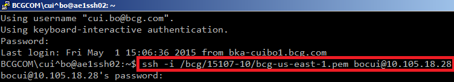

## Access Info (step-by-step in [CLI](http://en.wikipedia.org/wiki/Command-line_interface))

- Finally, type `bash` to start the Linux Shell and you are all set.

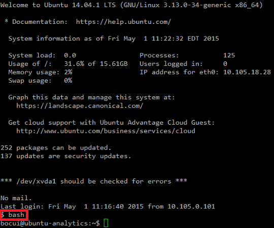

## Access outside BKA office

If you are travelling outside BKA office, you will need to be on special VPN to access.

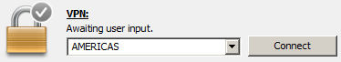

## System Configuration: Storage

There are two mounted EBS volumes:

1. 15GB for root
2. 60GB under `/home/data`

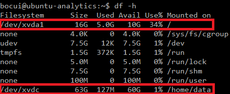

## System Configuration: Server Location

- HTTP Server: `/var/www/html/`

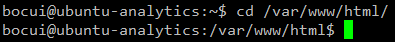

- Shiny Server: `/srv/shiny-server/`

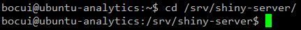